# Is the Points Tally in IPL Fair?

Cricket

IPL

Author

Anvit Aggarwal

Published

June 1, 2025

Two new teams, namely, Gujarat Titans and Lucknow Supergiants, were added to the IPL in 2022. Since then, the seasons have had 70-match seasons, which means that each team plays only 14 matches instead of the 18 it should have played if the tournament were a fair tournament. By a fair tournament, I mean that all teams would face each other twice, once at home and once away. Currently, the schedule of the IPL results in teams having different levels of opposition. Some teams have a harder schedule while other teams have an easier schedule. I think that this problem is solvable. I used a chess-like Elo-based algorithm to analyse the actual strengths of the teams. All teams were assigned an equal rating of 1200 at the beginning, and I ran the tournament and updated the ratings 1000 times to ensure that the ratings of each team converged to the level of their performance. You can view the graphs that show the ratings of each team after each iteration. Then, I predicted the number of wins of each team from the ratings. In each case, the number of predicted wins matches the actual number of wins. Then, I predicted what would have happened if the tournament were fair. You can view the code here:  
[Link to Code](https://colab.research.google.com/drive/1dL6TiElIQ2SKHf8p_KKPHnP791ggPCCy?usp=sharing)

Let’s go season by season:

## 2022:

Points Table:

[figure not shown]

Ratings:  
GT: 1355  
LSG: 1306  
RR: 1299  
RCB: 1254  
DC: 1200  
PBKS: 1200  
KKR: 1150  
SRH: 1149  
CSK: 1041  
MI: 1041

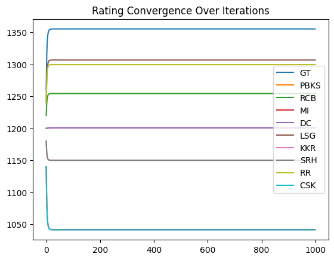

These are the ratings I obtained. We can see that GT is a distant first. Though we have a surprising result here. RR, which came second in the points table and ended as the runner-up in the competition, has a lower rating than LSG, which ended third on the points table and lost to RCB in the eliminator. To ensure that the ratings are accurate, I tried to reproduce the points table again using these ratings.

Expected wins based on Current Ratings:  
GT: 10.00  
RR: 9.00  
LSG: 9.00  
RCB: 8.00  
DC: 7.00  
PBKS: 7.00  
KKR: 6.00  
SRH: 6.00  
CSK: 4.00  
MI: 4.00

This matches the actual number of wins for each team in the tournament.  
If the tournament was a fair one, as I have defined earlier, the expected points of the teams would have been the following:

Fair Tournament Expected Points:  
GT: 25.8 | RR: 23.2  
LSG: 23.5 | RCB: 20.8  
DC: 18.0 | PBKS: 18.0  
KKR: 15.3 | SRH: 15.3  
CSK: 10.0 | MI: 10.0

## 2023:

Points table:

[figure not shown]

The case is more interesting in 2023.  
GT: 1353  
LSG: 1277  
CSK: 1272  
MI: 1251  
RR: 1201  
RCB: 1199  
KKR: 1152  
PBKS: 1150  
DC: 1100  
SRH: 1044

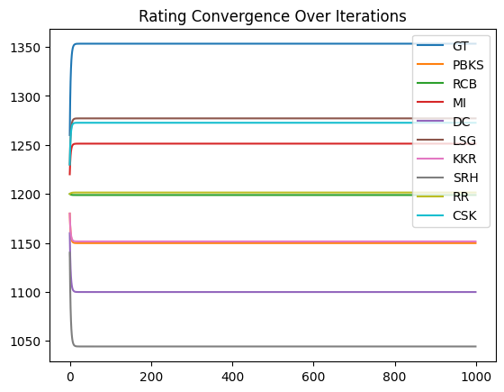

Expected Wins Based on Current Ratings:  
GT: 10.00  
CSK: 8.00  
LSG: 8.00  
MI: 8.00  
RR: 7.00  
RCB: 7.00  
KKR: 6.00  
PBKS: 6.00  
DC: 5.00  
SRH: 4.00  
Again, matches the actual number of wins. Thus, validating the ratings.

Fair Tournament Expected Points:  
GT: 25.9 | LSG: 22.1  
CSK: 21.9 | MI: 20.8  
RR: 18.1 | RCB: 17.9  
KKR: 15.4 | PBKS: 15.3  
DC: 12.7 | SRH: 10.0

Surprisingly, LSG again comes out ahead of CSK (the team that went on to win the IPL season that year).

## 2024:

Points Table

[figure not shown]

Ratings:  
KKR: 1378  
RR: 1263  
SRH: 1262  
LSG: 1206  
RCB: 1203  
DC: 1202  
CSK: 1193  
GT: 1124  
MI: 1066  
PBKS: 1104

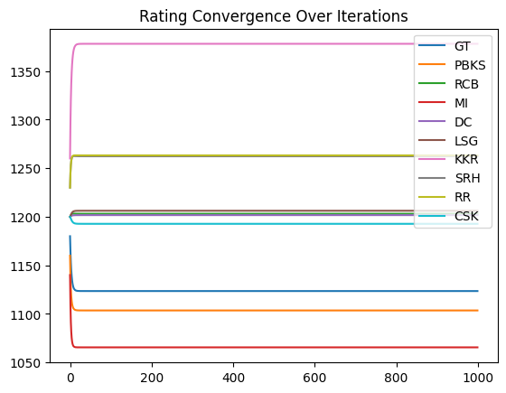

Expected Points Based on Current Ratings:  
KKR: 9.00  
SRH: 8.00  
RR: 8.00  
RCB: 7.00  
CSK: 7.00  
DC: 7.00  
LSG: 7.00  
GT: 5.00  
PBKS: 5.00  
MI: 4.00

Fair Tournament Expected Points:  
KKR: 27.0 | RR: 21.4  
SRH: 21.4 | LSG: 18.4  
RCB: 18.2 | DC: 18.1  
CSK: 17.6 | GT: 13.9  
MI: 11.0 | PBKS: 12.9

RR ends slightly ahead of SRH, but the difference is extremely small and can safely be neglected. Here as well, it is surprising to see LSG ahead of RCB.

We can safely say that LSG was pretty unlucky with its schedule in its first three seasons.

## 2025:

Points table:

[figure not shown]

Ratings:  
RCB: 1333  
PBKS: 1327  
GT: 1294  
MI: 1246  
DC: 1245  
LSG: 1171  
SRH: 1176  
KKR: 1116  
RR: 1048  
CSK: 1045

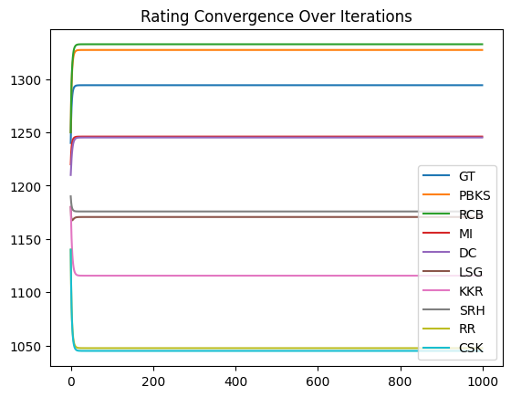

Expected Points Based on Current Ratings:  
PBKS: 9.00  
RCB: 9.00  
GT: 9.00  
MI: 8.00  
DC: 7.00  
SRH: 6.00  
LSG: 6.00  
KKR: 5.00  
RR: 4.00  
CSK: 4.00

Fair Tournament Expected Points:  
RCB: 24.8 | PBKS: 24.5  
GT: 22.9 | MI: 20.4  
DC: 20.4 | LSG: 16.4  
SRH: 16.7 | KKR: 13.6  
RR: 10.3 | CSK: 10.2

In this year’s IPL, DC would probably consider itself unlucky. Its performance was almost as good as MI but MI edged out ahead. One drawback of this algorithm is that it doesn’t take into account the margin of victory. Given MI’s significantly higher NRR, we could say that MI is probably still a significantly better team than DC.

I would like to explore the usefulness of a similar algorithm for the World Test Championship. Here, no weightage has been given to home and away matches. In WTC, perhaps, the distinction matters. For example, defeating India away is probably significantly easier than defeating India at home. In IPL, I assume that there isn’t much of a difference.